# README

## Labels for rivers in the ggplot2 framework

ggriverlab aims to introduce labels that follow lines to creat nice maps with ggplot2. Maybe I should learn how to use GIS dedicated softwares, but it is more to implement this function in R.

## First step: positioning labels

Before having functional labels and defining nice default parameters that give nice maps, I need to implement and test the basic postiioning of labels along a path.

### TO DO LIST

- $\checkmark$ make it work with point: place points along the path in place of letters;
- $\checkmark$ include in geom;
- $\Box$ make it work with entire labels as an option;
- $\checkmark$ make it work with letters;

### TO DO if the rest is done and clean

- $\Box$ make river specific geom (size~order);
- $\Box$ make interactive tool to test the parameters;
- $\checkmark$ find good default parameters;
- $\Box$ scale against text size or plot size ?;

## Demo

```r
library(ggriverlab)
library(riverdist)
```

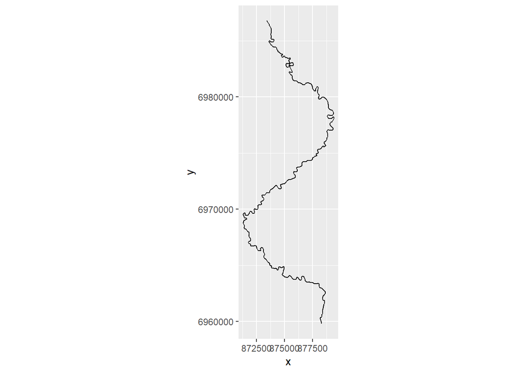

```r
library(ggplot2)
library(dplyr)
river <- as.data.frame(Gulk$lines[4])
colnames(river) <- c("x", "y")

ggplot(river, aes(x,y)) + geom_path() + coord_fixed()
```

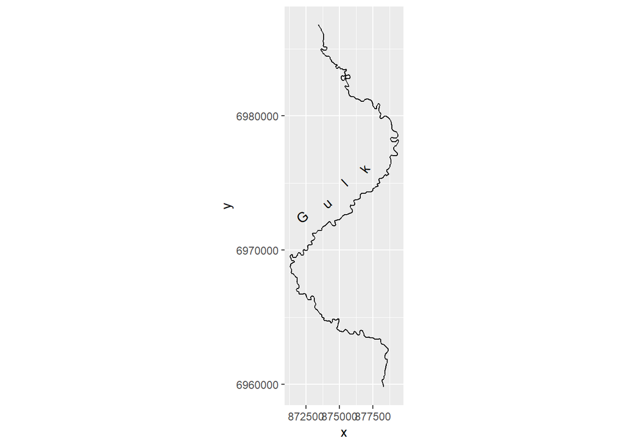

```r
ggplot(river, aes(x,y)) + geom_path() + coord_fixed() + geom_river_label(aes(label = "Gulk", offset = 0.24), reverse = F)
```

```r
?geom_river_label
```

```
## starting httpd help server ...
```

```
##  done
```

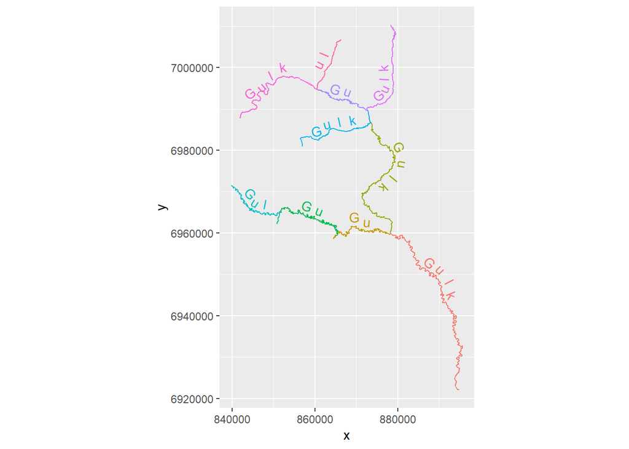

```r
# Plotting the full river

branches <- 1:14
branch_list <- lapply(branches, function(b, Gulk){
  river <- as.data.frame(Gulk$lines[b])
  colnames(river) <- c("x", "y")
  river$branch <- b
  return(river)
}, Gulk)
full_river<- do.call(rbind, branch_list)

ggplot(full_river, aes(x,y, group = branch, colour = as.factor(branch))) + geom_path() + coord_fixed() + geom_river_label(aes(label = "Gulk"), check_length = F) +
  theme(legend.position = "none")
```

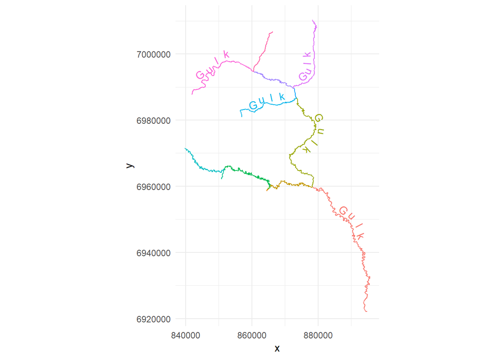

```r
# Check_length avoids to print labels that cannot fit the river portion.
ggplot(full_river, aes(x,y, group = branch, colour = as.factor(branch))) + geom_path() + coord_fixed() + geom_river_label(aes(label = "Gulk"), check_length = T) +
  theme_minimal() +theme(legend.position = "none")
```

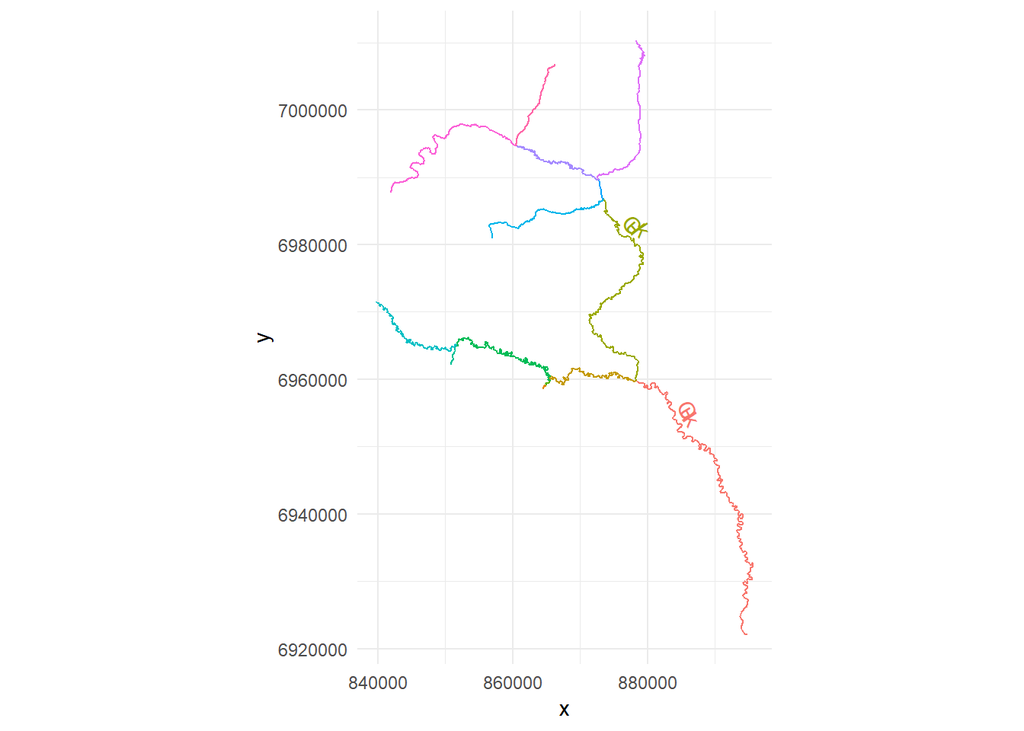

```r
ggplot(full_river, aes(x,y, group = branch, colour = as.factor(branch))) + geom_path() + coord_fixed() + geom_river_label(aes(label = "Gulk"), offset = 0.1, dist = 0.008, check_length = T) +
  theme_minimal() +theme(legend.position = "none")
```

The `geom_river_label` function can be used to plot multiple river, or branches at once. If the are too short, the label can be exclude thanks to the option `check_length = T`. The above code produce the following map of the river:

[figure not shown]

river labeling with ggriverlab

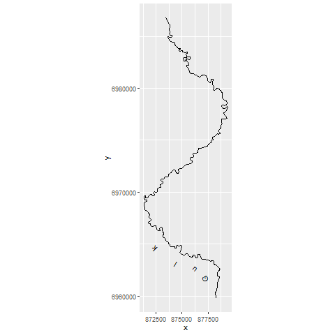

```r
# install.packages('devtools')
# devtools::install_github('thomasp85/gganimate')
library(gganimate)

# generate data for the animation
offsets <- seq(0.05, 0.9, length.out = 20)
list_data <- lapply(offsets, function(os, river){
  river$off <- os
  return(river)
}, river)
data_offset <- do.call(rbind, list_data)

anim <- ggplot(data_offset, aes(x,y)) + geom_path() + coord_fixed() + geom_river_label(aes(label = "Gulk", offset = off), relative = T, check_length = F, reverse = F, repeated = F)+
  transition_states(off, 1, 3)
anim
```

```r
anim_save("Images/moving_label_smooth.gif", last_animation())
```

The effect of the different parameters can be seen here:

[figure not shown]